# Topic 1: Introduction to R

# September 2018 report

#### Vectors

Vector is a sequence of data elements of the same type. We can have character vector, numeric vectors, logical vector. To create a vector, we use **c()**.

Now, we create a character vector

```r
programming_languages = c("C++", "R",  "Scala","Python", "JavaScript")
# print it
programming_languages
```

```
## [1] "C++"        "R"          "Scala"      "Python"     "JavaScript"
```

Here, **programming_languages** is a variable name and to the right of **=** are the values of this variable. Note, R considers **programming_languages** as a character vector.

If we create a a single value and assign to any variable, that variable is considered as a vector.

```r
income = 30000
is.vector(income)
```

```
## [1] TRUE
```

#### Integer vector

```r
price = c(60, 70, 30, 600)
# print it
price
```

```
## [1]  60  70  30 600
```

We could also label the values with the food names. We need to use **names(vector)** for this purpose. ow, we create a vector of food names.

```r
nam = c("sugar", "rice", "potato", "dry fish")
nam
```

```
## [1] "sugar"    "rice"     "potato"   "dry fish"
```

```r
names(price) = nam
# Print
price
```

```
##    sugar     rice   potato dry fish
##       60       70       30      600
```

```r
#nam
```

We can do all of these in one line.

```r
price2 = c(sugar = 60, rice = 70, potato  = 30, "dry fish" = 600)
price2
```

```
##    sugar     rice   potato dry fish
##       60       70       30      600
```

We can take a look at the structure of an R object using **str(object)**

```r
str(price2)
```

```
##  Named num [1:4] 60 70 30 600
##  - attr(*, "names")= chr [1:4] "sugar" "rice" "potato" "dry fish"
```

#### Vector arithmetic

We can do mathematical operations such as addition, subtraction, multiplication, division etc. with vectors

```r
item1 = 700
item2 = 650
total = item1 + item2
total
```

```
## [1] 1350
```

#### Element-wise opearation or vectorized operation

```r
a = c(10, 20, 30)
b = c(1,2,3)
a + b
```

```
## [1] 11 22 33
```

#### Subset by index

```r
price2 = c(sugar = 60, rice = 70, potato  = 30, "dry fish" = 600)
#price2
price2[1]
```

```
## sugar
##    60
```

We can also get the value of the first item by indexing by its name

```r
price2["sugar"]
```

```
## sugar
##    60
```

#### Exercise: Get the second item of price2 in 2 different ways. Give a try.

We can select multiple elements using c() in this way: **c(element_number1, element_number2)** inside

```r
price2[c(1,2)]
```

```
## sugar  rice
##    60    70
```

We can also use names to select multiple elements.

```r
price2[c("sugar", "rice")]
```

```
## sugar  rice
##    60    70
```

#### Selecting with deselecting or without selecting particular value or values

Use **-** as deselectg operator

We can use **-** before **c(element_number, …)**

```r
price2[-1]
```

```
##     rice   potato dry fish
##       70       30      600
```

#### Deselecting multiple items

Now, we select all but first and third element, we just add a **-** before **c(first element, third element)**

```r
price2
```

```
##    sugar     rice   potato dry fish
##       60       70       30      600
```

```r
price2[-c(1, 3)]
```

```
##     rice dry fish
##       70      600
```

But, we can’t use name similarly as positional index to deselect items. So, **price2[-c(“sugar”, “potato”)]**, will not work.

### Using Logical Vector for subsetting

```r
price2[c(FALSE, FALSE, TRUE, TRUE)]
```

```
##   potato dry fish
##       30      600
```

```r
price2
```

```
##    sugar     rice   potato dry fish
##       60       70       30      600
```

### Matrix – matrix()

Matrix is a 2 dimensional array of elements with fixed number of rows and columns. It can contain only one type of element; either numeric or character, or other type and it doesn’t allow a mix of different types of data elements.

We create a matrix using **matrix()** command. We can specify the number of rows using **nrow** and number of columns using **ncol** argument.

```r
number = matrix(1:25, nrow = 5)
# Print this matrix
number
```

```
##      [,1] [,2] [,3] [,4] [,5]
## [1,]    1    6   11   16   21
## [2,]    2    7   12   17   22
## [3,]    3    8   13   18   23
## [4,]    4    9   14   19   24
## [5,]    5   10   15   20   25
```

Let’s investigate what we have just done. **matrix()** tells that it is a matrix, **1:25** tellss that the matrix consists of numbers from 1 to 25 and **nrow = 5** tells that there will be 5 rows and these numbers have to be arranged column-wise. argument.

```r
mat2 = matrix(1:12, nrow = 4)
mat2
```

```
##      [,1] [,2] [,3]
## [1,]    1    5    9
## [2,]    2    6   10
## [3,]    3    7   11
## [4,]    4    8   12
```

The values here will be arranged columnwise.

If we want the values to be filled rowwise. We will use **byrow** argument for doing it.

```r
mat3 = matrix(1:12, nrow = 4, byrow = TRUE)
mat3
```

```
##      [,1] [,2] [,3]
## [1,]    1    2    3
## [2,]    4    5    6
## [3,]    7    8    9
## [4,]   10   11   12
```

### Naming a matrix using rownames() and colnames()

```r
matrix_arbitrary = matrix(1:16, nrow = 4, byrow = TRUE, dimnames = list(c("row1", "row2", "row3", "row4"),
                                                             c("col1", "col2", "col3", "col4")))
matrix_arbitrary
```

```
##      col1 col2 col3 col4
## row1    1    2    3    4
## row2    5    6    7    8
## row3    9   10   11   12
## row4   13   14   15   16
```

### Categorical variables as factors – factor()

We can use **factor()** to convert characters to factor. Please take note that R orders factor levels alphabetically.

```r
quality = c("bad", "good", "very bad", "very good", "medium")
quality = factor(quality)
quality
```

```
## [1] bad       good      very bad  very good medium
## Levels: bad good medium very bad very good
```

Let’s specify the order of levels using **levels** argument inside **factor()**.

```r
quality2 = factor(quality, levels = c("very bad", "bad", "medium", "good", "very good"))
quality2
```

```
## [1] bad       good      very bad  very good medium
## Levels: very bad bad medium good very good
```

```r
str(quality2)
```

```
##  Factor w/ 5 levels "very bad","bad",..: 2 4 1 5 3
```

We can also rename the levels in the following ways

```r
levels(quality2) = c("VB", "B", "M", "G", "VG")
quality2
```

```
## [1] B  G  VB VG M
## Levels: VB B M G VG
```

```r
# or we can do the following
quality3 = factor(quality, labels = c("VB", "B", "M", "G", "VG"))
quality
```

```
## [1] bad       good      very bad  very good medium
## Levels: bad good medium very bad very good
```

For making Ordered factors, use **ordered = TRUE** argument

```r
quality = c("bad", "good", "very bad", "very good", "medium")
quality2 = factor(quality, ordered = TRUE,
                   levels = c("very bad", "bad", "medium", "good", "very good"))
quality2
```

```
## [1] bad       good      very bad  very good medium
## Levels: very bad < bad < medium < good < very good
```

```r
quality2[1] < quality2[2]
```

```
## [1] TRUE
```

### Working with list – list()

#### List allows a variable to contain all types of R objects or a mix of different types of objects.

Example – Suppose, we want to group different employee information. We now use vector in the folllowing way:

```r
staff = c("Sohel Parvez", 2015, "Accountant", "Excellent")
```

In this case, as vector doesn’t permit mixing of different data types, the integer element is coerced to character which we don’t want. Using list, we can have preserve data types of different elements.

```r
staff = list("Sohel Parvez", 2016, "Accountant", "Excellent")
staff
```

```
## [[1]]
## [1] "Sohel Parvez"
##
## [[2]]
## [1] 2016
##
## [[3]]
## [1] "Accountant"
##
## [[4]]
## [1] "Excellent"
```

Now we put label on the staff variable.

```r
names(staff) = c("Name", "Start_year", "Position", "Performance")
```

Like vectors, we can also do these in one line in the following way.

```r
staff = list(name = "Sohel Parvez", start_year = 2016, position = "Accountant", performance = "Excellent")
```

List can be nested. Use **str()** to print the elements of a list in a compact way.

#### Accessing list element or indexing list.

```r
staff[1]
```

```
## $name
## [1] "Sohel Parvez"
```

```r
staff
```

```
## $name
## [1] "Sohel Parvez"
##
## $start_year
## [1] 2016
##
## $position
## [1] "Accountant"
##
## $performance
## [1] "Excellent"
```

We get the element as a list and not as a character string. To get the character string of names, we need to use **[]**. Here is how it looks like.

```r
staff[[1]]
```

```
## [1] "Sohel Parvez"
```

We can also get multiple elements as a list.

```r
staff[c(1,2)]
```

```
## $name
## [1] "Sohel Parvez"
##
## $start_year
## [1] 2016
```

Now, can we select mulltiple elements as character strings and not as list? NO! It throws error.

**staff[[c(1,2)]**

It might work when we have list within a list. Let’s define another employee.

```r
staff_new = list(name = "Andrew Ng", Start_year = 2009, position = "Chief of AI", performance = "Excellent", staff)
staff_new
```

```
## $name
## [1] "Andrew Ng"
##
## $Start_year
## [1] 2009
##
## $position
## [1] "Chief of AI"
##
## $performance
## [1] "Excellent"
##
## [[5]]
## [[5]]$name
## [1] "Sohel Parvez"
##
## [[5]]$start_year
## [1] 2016
##
## [[5]]$position
## [1] "Accountant"
##
## [[5]]$performance
## [1] "Excellent"
```

```r
second_staff_name = staff_new[[c(5,1)]]
# We can also do
second_staff_name = staff_new[[5]][[1]]
```

We can also subset by name.

```r
# Find the name of the first employee
staff_new[["name"]]
```

```
## [1] "Andrew Ng"
```

```r
# We can also use single bracket, returns a list
staff_new["name"]
```

```
## $name
## [1] "Andrew Ng"
```

We can also select subset using logicals. Logical works with single bracket

```r
staff_new[c(TRUE,  TRUE, TRUE, FALSE, FALSE)]
```

```
## $name
## [1] "Andrew Ng"
##
## $Start_year
## [1] 2009
##
## $position
## [1] "Chief of AI"
```

But logical doesn’t work with multiple brackets. **staff_new[[c(TRUE, FALSE, TRUE, FALSE, FALSE)]]** throws error. We can also use **$** to select element

```r
staff_new$name
```

```
## [1] "Andrew Ng"
```

Using **$**, we can also add element to the list

```r
salary = c(80000, 6000000)
staff_new$salary = salary
staff_new
```

```
## $name
## [1] "Andrew Ng"
##
## $Start_year
## [1] 2009
##
## $position
## [1] "Chief of AI"
##
## $performance
## [1] "Excellent"
##
## [[5]]
## [[5]]$name
## [1] "Sohel Parvez"
##
## [[5]]$start_year
## [1] 2016
##
## [[5]]$position
## [1] "Accountant"
##
## [[5]]$performance
## [1] "Excellent"
##
##
## $salary
## [1] 8e+04 6e+06
```

We also could do the same thing in the following way:

```r
staff_new[["salary"]] = salary
```

Suppose we have the following three lists providing information of educational qualification, address and salary of employees.

```r
edu = c("Masters", "PhD", "Masters", "BSc", "BBA")
address = c("Shewrapara", "Baridhara", "Gulshan 2", "Mirpur 1", "Uttara")
salary = c(50000, 100000, 50000, 30000, 20000, 25000)
employee_info = list(edu, address, salary)
```

Now, if we want the information of salary of second employee and address of fifth employee, we can do the following.

```r
employee_info[[3]][2]
```

```
## [1] 1e+05
```

```r
employee_info[[2]][5]
```

```
## [1] "Uttara"
```

### Data Frames

We create data frame using **data.frame()**

Suppose, we have conducted a survey and have information on *name*, *age*, *income* and *spending*. We will create a data frame information.

```r
name = c("Mustafa", "Mintu", "Ikram", "Shahadat", "Hakim", "Rony")
age = c(30, 24, 34, 45, 32, 52)
income = c(60000, 56000, 310000, 435600, 30000, 90500)
spending = c(50000, 45000, 200000, 300000, 28000, 77000)
information = data.frame(name, age, income, spending)
information
```

```
##       name age income spending
## 1  Mustafa  30  60000    50000
## 2    Mintu  24  56000    45000
## 3    Ikram  34 310000   200000
## 4 Shahadat  45 435600   300000
## 5    Hakim  32  30000    28000
## 6     Rony  52  90500    77000
```

We can also name data frame using **names()**.

```r
names(information) = c("Name", "Age", "Income", "Spending")
information
```

```
##       Name Age Income Spending
## 1  Mustafa  30  60000    50000
## 2    Mintu  24  56000    45000
## 3    Ikram  34 310000   200000
## 4 Shahadat  45 435600   300000
## 5    Hakim  32  30000    28000
## 6     Rony  52  90500    77000
```

We can also name data frames in the following way:

```r
information = data.frame(Name = name, Age = age, Income = income, Spending = spending)
information
```

```
##       Name Age Income Spending
## 1  Mustafa  30  60000    50000
## 2    Mintu  24  56000    45000
## 3    Ikram  34 310000   200000
## 4 Shahadat  45 435600   300000
## 5    Hakim  32  30000    28000
## 6     Rony  52  90500    77000
```

```r
str(information)
```

```
## 'data.frame':    6 obs. of  4 variables:
##  $ Name    : Factor w/ 6 levels "Hakim","Ikram",..: 4 3 2 6 1 5
##  $ Age     : num  30 24 34 45 32 52
##  $ Income  : num  60000 56000 310000 435600 30000 ...
##  $ Spending: num  50000 45000 200000 300000 28000 77000
```

We can see that *R* is considering *Name* as factor variable. We can change this behavior by setting **stringsAsFact0rs = FALSE**

```r
information = data.frame(Name = name, Age = age, Income = income, Spending = spending,
                         stringsAsFactors = FALSE)
information
```

```
##       Name Age Income Spending
## 1  Mustafa  30  60000    50000
## 2    Mintu  24  56000    45000
## 3    Ikram  34 310000   200000
## 4 Shahadat  45 435600   300000
## 5    Hakim  32  30000    28000
## 6     Rony  52  90500    77000
```

```r
# Now Name will be character
str(information)
```

```
## 'data.frame':    6 obs. of  4 variables:
##  $ Name    : chr  "Mustafa" "Mintu" "Ikram" "Shahadat" ...
##  $ Age     : num  30 24 34 45 32 52
##  $ Income  : num  60000 56000 310000 435600 30000 ...
##  $ Spending: num  50000 45000 200000 300000 28000 77000
```

To have a look at the first few observations of a data frame, use **head()** function.

```r
head(information)
```

```
##       Name Age Income Spending
## 1  Mustafa  30  60000    50000
## 2    Mintu  24  56000    45000
## 3    Ikram  34 310000   200000
## 4 Shahadat  45 435600   300000
## 5    Hakim  32  30000    28000
## 6     Rony  52  90500    77000
```

To know the number of rows and columns of a data frame, we use **dim()** function

```r
dim(information)
```

```
## [1] 6 4
```

We can subset data frame using (as in matrices) and also [] and $ (as in list). To select second row and third column, we write

```r
information[2, 3]
```

```
## [1] 56000
```

We can also do this

```r
information[2, "Income"]
```

```
## [1] 56000
```

```r
information[, "Age"]
```

```
## [1] 30 24 34 45 32 52
```

We can also select 2nd and 4th row and **Income** and **Age** at the same time

```r
information[c(2, 4), c("Income", "Age")]
```

```
##   Income Age
## 2  56000  24
## 4 435600  45
```

We can also use **$** and [] like below to select. In all of the following cases we get vector.

```r
information$Income
```

```
## [1]  60000  56000 310000 435600  30000  90500
```

```r
# or
information[["Income"]]
```

```
## [1]  60000  56000 310000 435600  30000  90500
```

```r
# or we can also use index
information[[3]]
```

```
## [1]  60000  56000 310000 435600  30000  90500
```

But if we use , we will get a data frame or a list.

```r
information["Income"]
```

```
##   Income
## 1  60000
## 2  56000
## 3 310000
## 4 435600
## 5  30000
## 6  90500
```

Now we will look at how we can add columns and rows.

### Adding column

The use of **$** and [] has the same effect of adding columns. Let’s suppose that we want to add column books to inform us how many books of the office employees owe.

```r
books = c(10, 12, 5, 2, 4, 3)
# Now add books to information dataframe
information$books = books
# or we can use
information[["books"]] = books
information
```

```
##       Name Age Income Spending books
## 1  Mustafa  30  60000    50000    10
## 2    Mintu  24  56000    45000    12
## 3    Ikram  34 310000   200000     5
## 4 Shahadat  45 435600   300000     2
## 5    Hakim  32  30000    28000     4
## 6     Rony  52  90500    77000     3
```

We can also use cbind() to add column to a dataframe.

```r
pencils = c(2, 4, 6, 1, 0, 3)
information = cbind(information, pencils)
information
```

```
##       Name Age Income Spending books pencils
## 1  Mustafa  30  60000    50000    10       2
## 2    Mintu  24  56000    45000    12       4
## 3    Ikram  34 310000   200000     5       6
## 4 Shahadat  45 435600   300000     2       1
## 5    Hakim  32  30000    28000     4       0
## 6     Rony  52  90500    77000     3       3
```

Similarly, we can also use rbind(). We just figured out that we have left out data for another employee Bulbul. We want to store his information in the information dataframe.

```r
# Note how we have to name the elements and have to use data.frame and not c()
bulbul = data.frame(Name = "Bulbul", Age = 40, Income = 115000, Spending = 90000, books = 5,
                    pencils = 4)
information = rbind(information, bulbul)
information
```

```
##       Name Age Income Spending books pencils
## 1  Mustafa  30  60000    50000    10       2
## 2    Mintu  24  56000    45000    12       4
## 3    Ikram  34 310000   200000     5       6
## 4 Shahadat  45 435600   300000     2       1
## 5    Hakim  32  30000    28000     4       0
## 6     Rony  52  90500    77000     3       3
## 7   Bulbul  40 115000    90000     5       4
```

## Basic Plots

Let’s generate some random variables first and make a scatter plot of these.

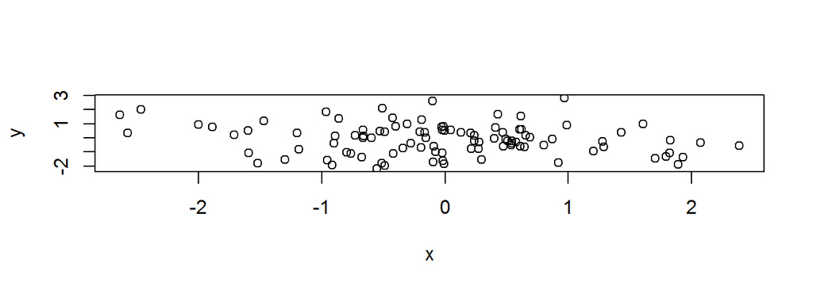

```r
x = rnorm(100)
y = rnorm(100)
plot(x, y)
```

Now we can modify this plot to have different colour by using **pch** for differnt plot sybbols and **col** for different plot colours

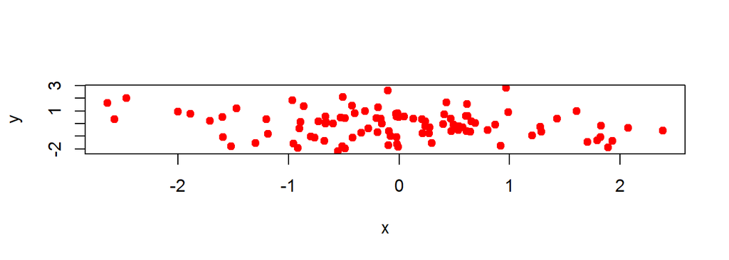

```r
plot(x, y, pch = 19, col = 'red')
```

We can make a line plot using **type = ‘l’** in **plot()** function

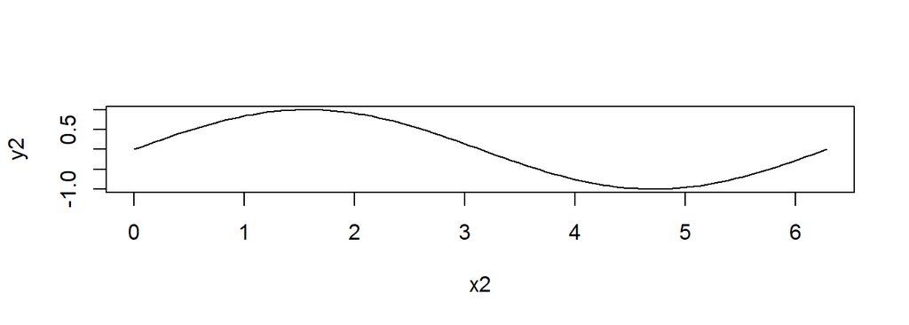

```r
x2 = seq(0, 2*pi, len = 100)
y2 = sin(x2)
plot(x2, y2, type = "l")
```

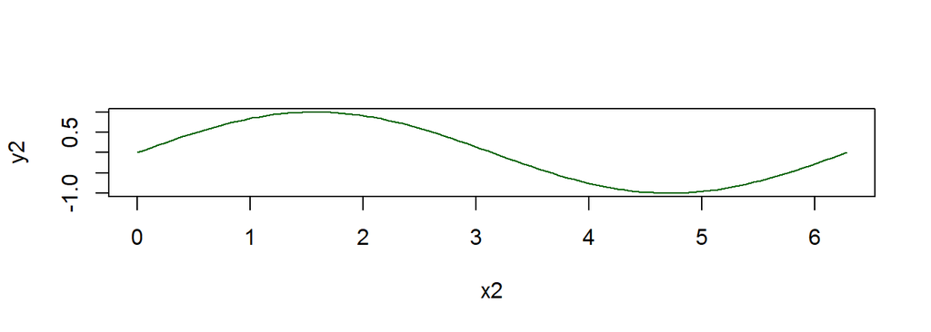

```r
plot(x2, y2, type = "l", col = "darkgreen")
```

Now we can further modify this plot by including points using **points** and giving the limit of y-axis by using **ylim=c(lower bound, upper bound)**

**col.main** specifies the color of the title. **cex.axis** determines the font size of axis labels.

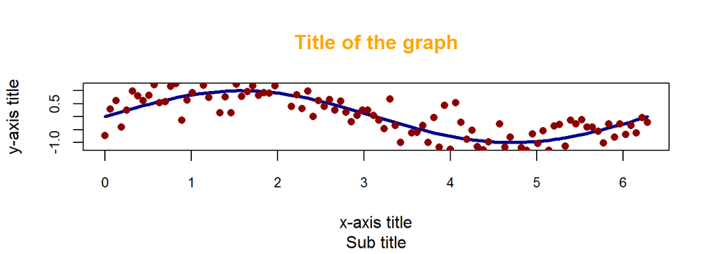

```r
plot(x2, y2, type = "l", col = "darkblue", lwd = 3, ylim = c(-1.2, 1.2), xlab = "x-axis title",
     ylab = "y-axis title", col.main = "Orange", main = "Title of the graph", cex.axis = 0.8,
     sub = "Sub title")
# Now we will add values from a normal distribution with mean 0 and variance 0.5
y3= y2 + rnorm(100, 0, 0.5)
# Now we can add these points to the line plot of y2 versus x2
points(x2, y3, pch = 16, col = "darkred")
```

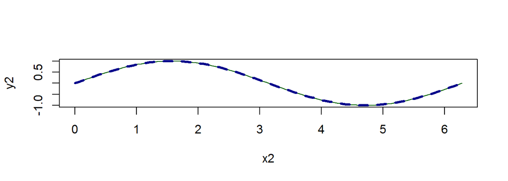

```r
y4 = sin(x2)
plot(x2, y2, type = "l",  col = "darkgreen")
lines(x2, y4, lwd = 3, lty = 2, col = "darkblue")
```

> Note that here **lines()** add line to an existing plot

We can also group multiple plots in a single figure using **par()**. Inside **par()**, use **mfrow = c(1,2)** to get a figure of 1 row and 2 columns. Here the fist value in *c(1,2)* in **mfrow = c(1,2)** corresponds to number of rows and the second corresponds to the number of columns. So, in other words, it is **mfrow = c(numberOfRows, numberOfColumns)**

Let’s have a look at the below example

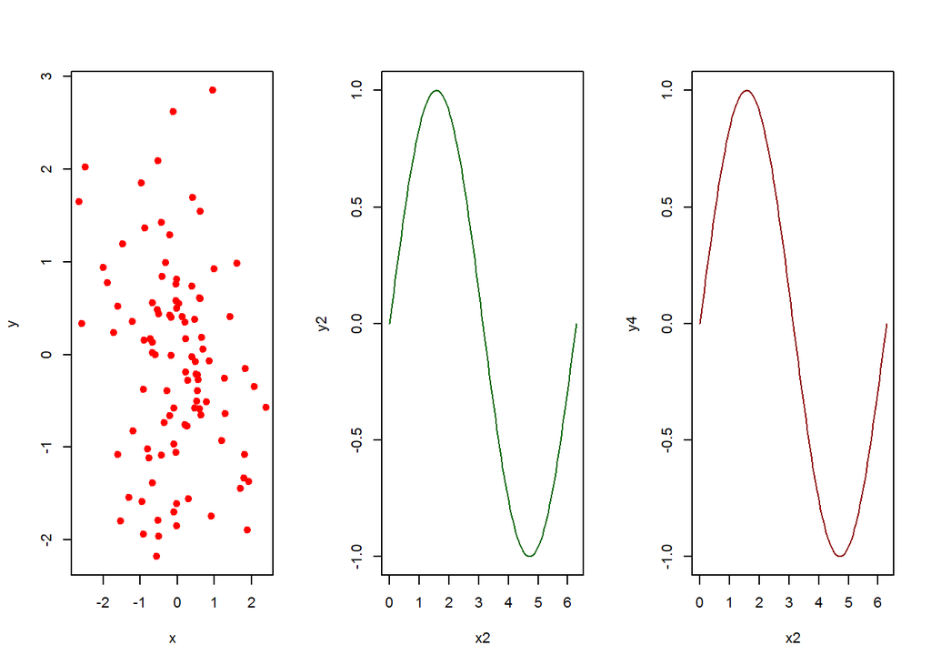

```r
# The below command will give us 1 row and 3 columns of plots in a single figure
par(mfrow = c(1,3))
plot(x, y, pch = 19, col = 'red')
plot(x2, y2, type = "l",  col = "darkgreen")
plot(x2, y4, type = "l",  col = "darkred")
```

```r
# Now, set to the default of 1 row and 1 column of plot in a figure
par(mfrow = c(1,1))
```

### # To reset the grid:

```r
#layout(1)
# Or
par(mfrow = c(1, 1))
```